# R Assignment 2

Wilson Tai

20/11/2022

```r
##loading the data, and getting general overview of it
s1995 <- read.delim("/Users/wilsontai/Downloads/s50_1995.txt", sep = "")
head(s1995)
```

```
##   alcohol drugs smoke sport
## 1       3     1     2     2
## 2       2     2     3     1
## 3       2     1     1     1
## 4       2     1     1     2
## 5       3     1     1     2
## 6       4     1     1     2
```

```r
summary(s1995)
```

```
##     alcohol         drugs          smoke          sport
##  Min.   :1.00   Min.   :1.00   Min.   :1.00   Min.   :1.00
##  1st Qu.:2.00   1st Qu.:1.00   1st Qu.:1.00   1st Qu.:1.25
##  Median :3.00   Median :1.00   Median :1.00   Median :2.00
##  Mean   :2.88   Mean   :1.46   Mean   :1.38   Mean   :1.74
##  3rd Qu.:4.00   3rd Qu.:2.00   3rd Qu.:1.00   3rd Qu.:2.00
##  Max.   :5.00   Max.   :4.00   Max.   :3.00   Max.   :2.00
```

```r
attach(s1995)
str(s1995)
```

```
## 'data.frame':    50 obs. of  4 variables:
##  $ alcohol: int  3 2 2 2 3 4 4 4 2 4 ...
##  $ drugs  : int  1 2 1 1 1 1 3 3 1 1 ...
##  $ smoke  : int  2 3 1 1 1 1 1 3 1 1 ...
##  $ sport  : int  2 1 1 2 2 2 1 2 2 2 ...
```

The above structure function says that all the variables are integers. We will take note of this in preparation for Question 1.

```r
##Question 1
s1995$sport <- factor(s1995$sport,levels = c(1,2),
                      label = c("Not Regular","Regular"),
                      ordered = T)
s1995$alcohol <- factor(s1995$alcohol,levels = c(1,2,3,4,5),
                        label = c("None","Yearly","Monthly","Weekly","MulptipleWeekly"),
                        ordered = T)
s1995$smoke <- factor(s1995$smoke,levels = c(1,2,3),
                      label = c("None","Occasional","Regular"),
                      ordered = T)
s1995$drugs <- factor(s1995$drugs,levels = c(1,2,3,4),
                      label = c("None","Tried", "Occasional", "Regular"),
                      ordered = T)
```

In the above, I am converting each variable to something qualitative (factor). More appropriately, I am giving a label for each level within the variable. Thus, in the following output, when I insert the structure function, I should obtain that they are now all ‘ordered factors’, unlike the prior: ‘integers’.

```r
head(s1995)
```

```
##   alcohol drugs      smoke       sport
## 1 Monthly  None Occasional     Regular
## 2  Yearly Tried    Regular Not Regular
## 3  Yearly  None       None Not Regular
## 4  Yearly  None       None     Regular
## 5 Monthly  None       None     Regular
## 6  Weekly  None       None     Regular
```

```r
tail(s1995)
```

```
##    alcohol drugs smoke       sport
## 45  Yearly  None  None     Regular
## 46  Yearly  None  None Not Regular
## 47  Yearly  None  None Not Regular
## 48  Yearly  None  None     Regular
## 49    None  None  None Not Regular
## 50    None Tried  None     Regular
```

```r
str(s1995)
```

```
## 'data.frame':    50 obs. of  4 variables:
##  $ alcohol: Ord.factor w/ 5 levels "None"<"Yearly"<..: 3 2 2 2 3 4 4 4 2 4 ...
##  $ drugs  : Ord.factor w/ 4 levels "None"<"Tried"<..: 1 2 1 1 1 1 3 3 1 1 ...
##  $ smoke  : Ord.factor w/ 3 levels "None"<"Occasional"<..: 2 3 1 1 1 1 1 3 1 1 ...
##  $ sport  : Ord.factor w/ 2 levels "Not Regular"<..: 2 1 1 2 2 2 1 2 2 2 ...
```

As expected.

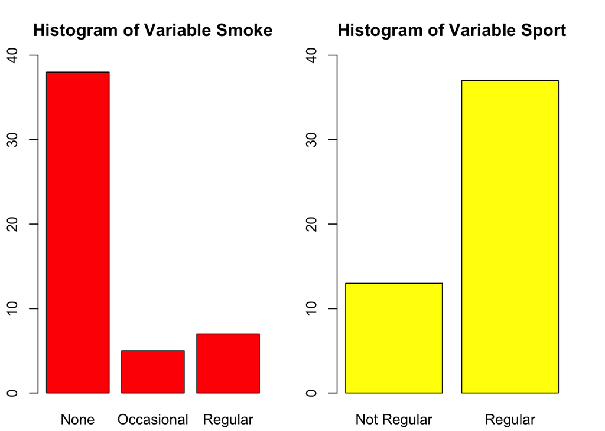

```r
##Question 2
##Base R required
par(mfrow = c(1,2), mar = c(2,2,3,2), oma=c(0.2,0.2,0.2,0.2)) #editing the layout of my plot
plot(s1995$smoke, col = "red", ylim = c(0,40),
     ylab = "Frequency",
     main = "Histogram of Variable Smoke")
plot(s1995$sport, col = "yellow", ylim = c(0,40),
     ylab = "Frequency",
     main = "Histogram of Variable Sport")
```

We have plotted the graphs in the one plot. On the Smoke Histogram, we can see that the vast majority of students do not smoke, whilst a few smokers represent a conglomerate of Occasional and Regular (Can you believe these observations are just 13 year olds?!). And on the right hand side of the graph, students who participate in sport regularly accounts for more than double of those who don’t.

Moving on to Question 3:

```r
##Question 3
at_least_occasional <- ifelse(s1995$smoke != "None", 1, 0)
sum(at_least_occasional)
```

```
## [1] 12
```

We are first asked to find students who smoke AT LEAST occasionally: occasionally or greater. Thus, the lowest observation should smoke occasionally. This must imply that the only label ‘None’ should be ruled out. I thus use a simple dummy variable approach to disparate these two types of observations. As a result, I obtained a total of 12 students who smoke at least occasionally.

```r
sum(at_least_occasional)/nrow(s1995) ##proportion formula: x/n
```

```
## [1] 0.24
```

And from this result, I thus divide by the number of rows our dataframe s1995 has (50), in which I subsequently obtain 0.24. This means the 24% of students from our sample smoke at least occasionally.

For the following subquestion, we must conform to two conditions: smokes at least occasionally (like the prior) and must also play sport regularly. Our code to achieve this is thus:

```r
##
sport$occasional_sport <- ifelse(s1995$smoke != "None" & s1995$sport == "Regular", 1,0)
sport$occasional_sport ##checking if results are as they should be
```

```
##  [1] 1 0 0 0 0 0 0 1 0 0 1 1 0 0 1 1 0 0 0 0 0 0 1 0 0 1 0 0 0 0 0 0 0 0 0 0 0 0
## [39] 0 0 1 0 0 0 0 0 0 0 0 0
```

```r
sum(sport$occasional_sport)/nrow(s1995)  ##proportion implemented again
```

```
## [1] 0.18
```

In the following question, we are required to create an S3 class.

```r
##Question 4
s50survey <- function(x) {
  inputdata <- sapply(x, function(x) t(sapply(x, table)))
  survey <- sapply(inputdata, function(x) colSums(prop.table(x)))
  returnValue(survey)
}
```

In the first line (inputdata as object), I used sapply to a specific something, that something being the piece of code after it. This function in the first line essentially says that we want to find the total of each label and then convert it into a table for viewing purposes.

The following line uses sapply function again, but with the object derived from the first line. With this, I construct another sub-function, which tells R to sum the column of the prop table. The algorithm ends with returning the proportion of each variable.

And then checking our function with respect to our dataframe s1995:

```r
s50survey(s1995)
```

```
## $alcohol
##            None          Yearly         Monthly          Weekly MulptipleWeekly
##            0.10            0.32            0.24            0.28            0.06
##
## $drugs
##       None      Tried Occasional    Regular
##       0.72       0.12       0.14       0.02
##
## $smoke
##       None Occasional    Regular
##       0.76       0.10       0.14
##
## $sport
## Not Regular     Regular
##        0.26        0.74
```

And doing a robustness check for an arbitary label:

```r
SportREGULAR <- ifelse(s1995$sport == "Regular", 1, 0)
SportREGULAR
```

```
##  [1] 1 0 0 1 1 1 0 1 1 1 1 1 0 0 1 1 0 0 1 1 1 0 1 1 1 1 1 1 1 1 1 1 1 1 1 1 1 1
## [39] 1 1 1 0 1 0 1 0 0 1 0 1
```

```r
sum(SportREGULAR)/nrow(s1995)
```

```
## [1] 0.74
```

As before.

We have thus created a function that provides a quick and dirty summary for proportion of labels for each variable.

The following question requires us to find the proportion of students who never smoked cannabis. We apply the same methodology as Question 3:

```r
##Question 5
##if never smoked cannabis, then assign observation to 1, else 0.
no_cannabis <- ifelse(s1995$drugs == "None", 1, 0)
no_cannabis
```

```
##  [1] 1 0 1 1 1 1 0 0 1 1 0 0 0 1 1 0 1 1 1 1 1 1 0 1 1 0 1 1 0 1 1 1 1 1 0 1 1 1
## [39] 1 1 1 0 1 0 1 1 1 1 1 0
```

```r
sum(no_cannabis)/nrow(s1995)
```

```
## [1] 0.72
```

72% of students did not smoke cannabis, which implies that 28% of 13 year olds has tried at least once!

Question 6 is just a reiteration of what we done before. Rather than writing these long paragraphs that hopefully has not bored the reader yet, I am just going to implement laconic comments instead.

```r
##Question 6
s1997 <- read.delim("/Users/wilsontai/Downloads/s50_1997.txt", sep = "")
attach(s1997) ##attaching this new data
str(s1997) ##observing structure: all integers
```

```
## 'data.frame':    50 obs. of  4 variables:
##  $ alcohol: int  3 2 3 2 4 4 3 4 2 4 ...
##  $ drugs  : int  1 3 1 1 3 1 2 3 1 1 ...
##  $ smoke  : int  1 3 1 1 1 3 3 3 1 2 ...
##  $ sport  : int  1 1 1 1 2 2 2 2 1 2 ...
```

```r
head(s1997) ##looking top few observations
```

```
##   alcohol drugs smoke sport
## 1       3     1     1     1
## 2       2     3     3     1
## 3       3     1     1     1
## 4       2     1     1     1
## 5       4     3     1     2
## 6       4     1     3     2
```

```r
##giving them appropriate levels and labels like in Question 1
s1997$sport <- factor(s1997$sport,levels = c(1,2),
                      label = c("Not Regular","Regular"),
                      ordered = T)
s1997$alcohol <- factor(s1997$alcohol,levels = c(1,2,3,4,5),
                        label = c("None","Yearly","Monthly","Weekly","Alcoholic"),
                        ordered = T)
s1997$smoke <- factor(s1997$smoke,levels = c(1,2,3),
                      label = c("None","Occasional","Regular"),
                      ordered = T)
s1997$drugs <- factor(s1997$drugs,levels = c(1,2,3,4),
                      label = c("None","Tried", "Occasional", "Regular"),
                      ordered = T)
head(s1997)
```

```
##   alcohol      drugs   smoke       sport
## 1 Monthly       None    None Not Regular
## 2  Yearly Occasional Regular Not Regular
## 3 Monthly       None    None Not Regular
## 4  Yearly       None    None Not Regular
## 5  Weekly Occasional    None     Regular
## 6  Weekly       None Regular     Regular
```

```r
tail(s1997)
```

```
##    alcohol      drugs   smoke       sport
## 45  Yearly       None    None     Regular
## 46  Yearly       None    None Not Regular
## 47  Yearly       None    None Not Regular
## 48  Weekly       None    None     Regular
## 49 Monthly       None    None Not Regular
## 50 Monthly Occasional Regular Not Regular
```

```r
str(s1997) ##Noticed the change again: integer to ordered factor
```

```
## 'data.frame':    50 obs. of  4 variables:
##  $ alcohol: Ord.factor w/ 5 levels "None"<"Yearly"<..: 3 2 3 2 4 4 3 4 2 4 ...
##  $ drugs  : Ord.factor w/ 4 levels "None"<"Tried"<..: 1 3 1 1 3 1 2 3 1 1 ...
##  $ smoke  : Ord.factor w/ 3 levels "None"<"Occasional"<..: 1 3 1 1 1 3 3 3 1 2 ...
##  $ sport  : Ord.factor w/ 2 levels "Not Regular"<..: 1 1 1 1 2 2 2 2 1 2 ...
```

Again, notice the change from integers to ordered factor like Question 1. As we know, this is because of the factor function that was implemented.

I then reuse the s50survey function I created a few questions prior:

```r
s50survey(s1997) ##And reusing the function I created a few questions ago
```

```
## $alcohol
##      None    Yearly   Monthly    Weekly Alcoholic
##      0.02      0.18      0.34      0.34      0.12
##
## $drugs
##       None      Tried Occasional    Regular
##       0.52       0.14       0.34       0.00
##
## $smoke
##       None Occasional    Regular
##       0.62       0.04       0.34
##
## $sport
## Not Regular     Regular
##        0.62        0.38
```

Which provides again provides us a quick and dirty overview of the summary proportion of each variable.

We now move onto Question 7 which talks about rate of change.

```r
##Question 7
s1997$sportreg <- ifelse(s1997$sport == "Regular",1,0)
s1995$sportreg <- ifelse(s1995$sport == "Regular",1,0)
##Formula for change: (B-A)/A
(sum(s1997$sportreg) - sum(s1995$sportreg))/sum(s1995$sportreg) ##fell by approximately 49%
```

```
## [1] -0.4864865
```

Students who participated in sports regularly in 1997 fell by approximately 49% relative to two years ago.